# AI in Pharm 2 - data prep

To start AI/ML journey in any field not only pharmaceutical sciences we need DATA. Yes, it's sad to say but to make any inference with fancy like AI/ML tools we need some knowledge, database preparation. Propper data acquisition and collection are quite challenging... We will not spend much time in our class in practical data collection but we have to exclaim, that data is crucial for further exploration models development and actually everything hidden under fancy Artificial Intelligence term. Just to show how this step is important is worth to remember sentence: "rubbish in, rubbish out"

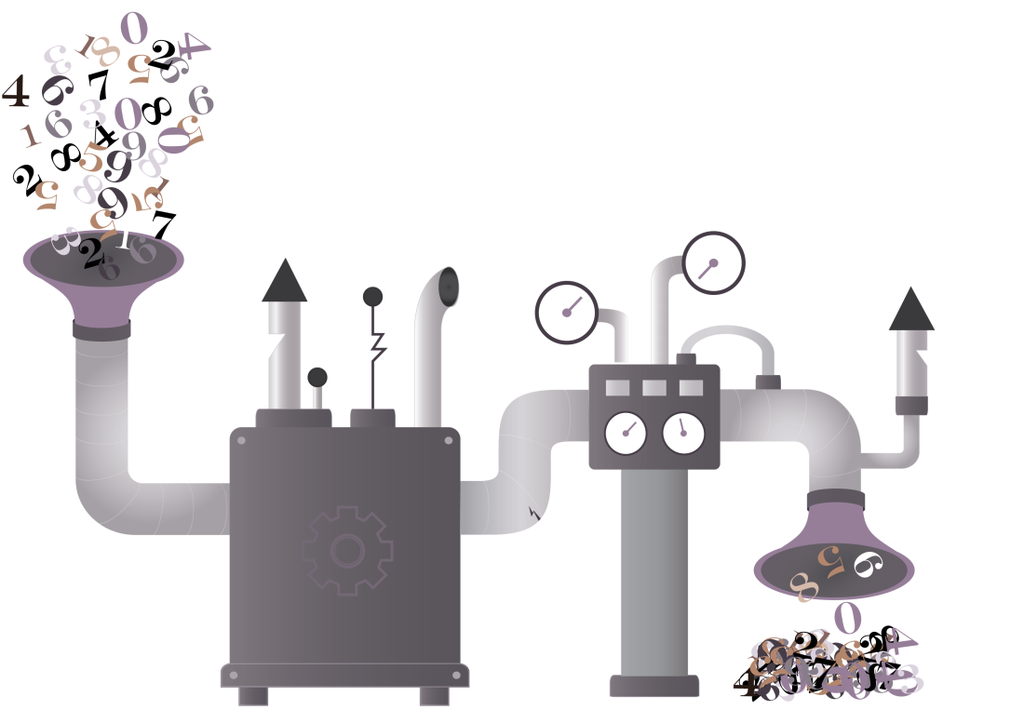

Source:https://www.cleanpng.com/png-garbage-in-garbage-out-management-computer-data-co-1816657/

So assuming we have some data lets try to load it, explore and prepare for further use. Please take some advice and use documentation. We will use 2 commands and try modify different arguments to properly load our data. Lets start from simpler command read.csv() and take a look into documentation:

read.csv(file, header = TRUE, sep = ",", quote = "\"", dec = ".", fill = TRUE, comment.char = "", ...)

And take a look into a more flexible and complicated function: read.table():

read.table(file, header = FALSE, sep = "", quote = "\"'", dec = ".", numerals = c("allow.loss", "warn.loss", "no.loss"), row.names, col.names, as.is = !stringsAsFactors, na.strings = "NA", colClasses = NA, nrows = -1, skip = 0, check.names = TRUE, fill = !blank.lines.skip, strip.white = FALSE, blank.lines.skip = TRUE, comment.char = "#", allowEscapes = FALSE, flush = FALSE, stringsAsFactors = default.stringsAsFactors(), fileEncoding = "", encoding = "unknown", text, skipNul = FALSE

```r
raw_data<-read.csv("BBB_raw_data.csv")
```

```r
summary(raw_data)
```

```
      tpsa            nbasic          negative           vsa_hyd
 Min.   :  3.24   Min.   :0.0000   Min.   :0.000000   Min.   : 65.44
 1st Qu.: 35.94   1st Qu.:0.0000   1st Qu.:0.000000   1st Qu.:164.33
 Median : 46.18   Median :0.0000   Median :0.000000   Median :231.45
 Mean   : 52.87   Mean   :0.3654   Mean   :0.004808   Mean   :234.94
 3rd Qu.: 72.68   3rd Qu.:1.0000   3rd Qu.:0.000000   3rd Qu.:299.66
 Max.   :166.75   Max.   :1.0000   Max.   :1.000000   Max.   :493.00

     a_aro            weight        peoe_vsa.0       peoe_vsa.1
 Min.   : 0.000   Min.   :129.2   Min.   :  0.00   Min.   :  0.00
 1st Qu.: 6.000   1st Qu.:250.4   1st Qu.: 38.73   1st Qu.: 41.22
 Median :11.000   Median :304.3   Median : 63.84   Median : 75.77
 Mean   : 9.707   Mean   :310.6   Mean   : 63.18   Mean   : 75.77
 3rd Qu.:12.000   3rd Qu.:376.9   3rd Qu.: 84.87   3rd Qu.:107.08
 Max.   :21.000   Max.   :671.9   Max.   :149.28   Max.   :162.36

   peoe_vsa.2       peoe_vsa.3      peoe_vsa.4       peoe_vsa.5
 Min.   :  0.00   Min.   : 0.00   Min.   : 0.000   Min.   : 0.00
 1st Qu.:  0.00   1st Qu.: 0.00   1st Qu.: 0.000   1st Qu.: 0.00
 Median :  9.81   Median : 6.70   Median : 0.000   Median : 0.00
 Mean   : 14.95   Mean   :10.98   Mean   : 5.786   Mean   : 3.96
 3rd Qu.: 24.87   3rd Qu.:17.24   3rd Qu.:10.324   3rd Qu.: 6.70
 Max.   :120.05   Max.   :94.24   Max.   :44.788   Max.   :29.42

   peoe_vsa.6      peoe_vsa.0.1     peoe_vsa.1.1     peoe_vsa.2.1
 Min.   : 0.000   Min.   :  0.00   Min.   :  0.00   Min.   : 0.000
 1st Qu.: 8.619   1st Qu.: 24.51   1st Qu.: 24.51   1st Qu.: 0.000
 Median :17.238   Median : 39.84   Median : 54.09   Median : 0.000
 Mean   :16.365   Mean   : 44.49   Mean   : 55.57   Mean   : 2.992
 3rd Qu.:24.301   3rd Qu.: 61.27   3rd Qu.: 73.53   3rd Qu.: 0.000
 Max.   :68.301   Max.   :143.62   Max.   :227.81   Max.   :44.603

  peoe_vsa.3.1     peoe_vsa.4.1     peoe_vsa.5.1     peoe_vsa.6.1
 Min.   : 0.000   Min.   : 0.000   Min.   : 0.000   Min.   : 0.000
 1st Qu.: 0.000   1st Qu.: 0.000   1st Qu.: 0.000   1st Qu.: 0.000
 Median : 0.000   Median : 0.000   Median : 2.504   Median : 2.504
 Mean   : 3.008   Mean   : 4.090   Mean   : 8.295   Mean   : 6.419
 3rd Qu.: 0.000   3rd Qu.: 5.683   3rd Qu.:13.567   3rd Qu.:10.015
 Max.   :35.863   Max.   :35.182   Max.   :54.268   Max.   :49.076

```

[output cut: 217 more lines]

```
 Min.   :  0.00   Min.   : 0.000   Min.   :  0.00   Min.   : 0.000
 1st Qu.:  0.00   1st Qu.: 4.423   1st Qu.:  0.00   1st Qu.: 0.000
 Median :  0.00   Median : 7.728   Median : 21.93   Median : 3.411
 Mean   : 12.54   Mean   :10.660   Mean   : 28.78   Mean   :11.576
 3rd Qu.: 21.42   3rd Qu.:14.810   3rd Qu.: 49.40   3rd Qu.:18.819
 Max.   :105.21   Max.   :61.979   Max.   :151.82   Max.   :78.612

     logBBB
 Min.   :-2.15000
 1st Qu.:-0.42250
 Median : 0.02000
 Mean   :-0.01889
 3rd Qu.: 0.53000
 Max.   : 1.64000
 NA's   :1
```

```r
is.na(raw_data)
```

[output not shown]

```r
sum(is.na(raw_data))
```

1

```r
raw_data[1]
```

| tpsa |
| --- |
| 12.03 |
| 49.33 |
| 50.53 |
| 37.39 |
| 37.39 |
| 37.39 |
| 52.57 |
| 40.54 |
| 15.27 |
| 32.78 |
| 64.16 |
| 26.79 |
| 41.46 |
| 83.72 |
| 83.85 |
| 83.85 |
| 83.85 |
| 87.34 |
| 87.34 |
| 87.09 |
| 41.57 |
| 6.48 |
| 9.72 |
| 38.77 |
| 77.05 |
| 32.78 |
| 166.75 |
| 97.28 |
| 21.26 |
| 41.49 |
| ... |
| 36.42 |
| 57.53 |
| 135.00 |
| 93.03 |
| 92.79 |
| 100.81 |
| 135.00 |
| 103.89 |
| 87.34 |
| 90.37 |
| 41.93 |
| 75.27 |
| 58.20 |
| 12.03 |
| 41.57 |
| 64.43 |
| 12.03 |
| 72.68 |
| 53.01 |
| 87.05 |
| 64.43 |
| 19.37 |
| 12.47 |
| 83.56 |
| 81.65 |
| 32.70 |
| 3.24 |
| 32.34 |
| 37.30 |
| 64.43 |

```r
raw_data$tpsa
```

1. 12.03

2. 49.330002

3. 50.529999

4. 37.389999

5. 37.389999

6. 37.389999

7. 52.57

8. 40.540001

9. 15.27

10. 32.779999

11. 64.160004

12. 26.790001

13. 41.459999

14. 83.720001

15. 83.849998

16. 83.849998

17. 83.849998

18. 87.339996

19. 87.339996

20. 87.089996

21. 41.57

22. 6.48

23. 9.72

24. 38.77

25. 77.050003

26. 32.779999

27. 166.75

28. 97.279999

29. 21.26

30. 41.490002

31. 58.119999

32. 117.510002

33. 110.599998

34. 55.560001

35. 24.5

36. 32.700001

37. 41.490002

38. 36.419998

39. 55.43

40. 39.68

41. 32.34

42. 75.269997

43. 84.389999

44. 33.290001

45. 74.160004

46. 33.290001

47. 67.43

48. 33.290001

49. 33.290001

50. 42.52

51. 42.52

52. 42.52

53. 23.549999

54. 29.950001

55. 24.5

56. 40.619999

57. 118.029999

58. 66.480003

59. 89.75

60. 55.400002

61. 98.540001

62. 37.299999

63. 101.900002

64. 61.880001

65. 70.669998

66. 44.73

67. 46.18

68. 131.190002

69. 75.809998

70. 51.110001

71. 46.18

72. 46.18

73. 46.18

74. 46.18

75. 46.18

76. 53.599998

77. 83.559998

78. 40.16

79. 38.91

80. 38.91

81. 64.629997

82. 24.5

83. 59.32

84. 35.5

85. 52.049999

86. 55.43

87. 91.480003

88. 34.029999

89. 29.26

90. 15.27

91. 29.26

92. 28.16

93. 69.260002

94. 72.5

95. 12.03

96. 36.419998

97. 72.419998

98. 40.619999

99. 49.41

100. 37.810001

101. 36.419998

102. 6.48

103. 74.790001

104. 52.8654324230769

105. 43.07

106. 43.07

107. 84.580002

108. 46.330002

109. 133.080002

110. 84.32

111. 23.549999

112. 41.93

113. 36.419998

114. 78.010002

115. 58.860001

116. 87.660004

117. 36.419998

118. 36.419998

119. 36.419998

120. 36.419998

121. 36.419998

122. 43.32

123. 32.669998

124. 36.419998

125. 34.029999

126. 33.200001

127. 24.92

128. 75.269997

129. 40.619999

130. 55.84

131. 15.27

132. 3.24

133. 6.48

134. 6.48

135. 63.599998

136. 43.700001

137. 62.299999

138. 88.889999

139. 66.839996

140. 52.93

141. 75.269997

142. 75.269997

143. 40.540001

144. 73.099998

145. 41.490002

146. 55.84

147. 6.48

148. 68.529999

149. 43.779999

150. 16.129999

151. 24.92

152. 66.480003

153. 45.59

154. 37.299999

155. 24.92

156. 58.200001

157. 75.269997

158. 75.269997

159. 78.82

160. 61.82

161. 30.17

162. 72.68

163. 28.6

164. 36.419998

165. 36.419998

166. 36.419998

167. 30.18

168. 50.41

169. 50.41

170. 26.93

171. 61.689999

172. 72.68

173. 38.91

174. 16.129999

175. 50.720001

176. 36.419998

177. 83.580002

178. 70.589996

179. 35.939999

180. 36.419998

181. 57.529999

182. 135

183. 93.029999

184. 92.790001

185. 100.809998

186. 135

187. 103.889999

188. 87.339996

189. 90.370003

190. 41.93

191. 75.269997

192. 58.200001

193. 12.03

194. 41.57

195. 64.43

196. 12.03

197. 72.68

198. 53.009998

199. 87.050003

200. 64.43

201. 19.370001

202. 12.47

203. 83.559998

204. 81.650002

205. 32.700001

206. 3.24

207. 32.34

208. 37.299999

209. 64.43

```r
dim(raw_data)
```

1. 209

2. 135

```r
raw_data[10,]
```

|  | tpsa | nbasic | negative | vsa_hyd | a_aro | weight | peoe_vsa.0 | peoe_vsa.1 | peoe_vsa.2 | peoe_vsa.3 | ... | ctdh | ctaa | mchg | achg | rdta | n_sp2 | n_sp3 | o_sp2 | o_sp3 | logBBB |
| --- | --- | --- | --- | --- | --- | --- | --- | --- | --- | --- | --- | --- | --- | --- | --- | --- | --- | --- | --- | --- | --- |
| 10 | 32.78 | 1 | 0 | 252.9569 | 6 | 251.35 | 85.5588 | 97.58976 | 7.411346 | 0 | ... | 0 | 3 | 0 | 0 | 0 | 0 | 4.3804 | 23.1112 | 3.9461 | 0.88 |

```r
raw_data[,134]
```

1. 0

2. 33.613499

3. 27.545099

4. 15.1316

5. 15.1333

6. 15.1333

7. 29.729099

8. 18.819201

9. 0

10. 3.9461

11. 27.6182

12. 0

13. 0

14. 0

15. 0

16. 0

17. 0

18. 7.4357

19. 4.9073

20. 0

21. 15.1333

22. 0

23. 0

24. 38.298599

25. 13.1949

26. 3.9461

27. 14.6267

28. 40.571602

29. 11.8204

30. 26.5173

31. 0

32. 62.807201

33. 71.394402

34. 24.102301

35. 3.8361

36. 26.5173

37. 24.1003

38. 0

39. 0

40. 0

41. 0

42. 0

43. 58.945301

44. 4.8351

45. 14.4811

46. 9.6436

47. 4.8351

48. 5.9488

49. 9.6397

50. 19.6859

51. 24.0068

52. 24.1901

53. 0

54. 28.670401

55. 5.154

56. 0

57. 12.6328

58. 0

59. 0

60. 9.393

61. 9.3913

62. 26.653799

63. 48.459099

64. 3.1723

65. 4.3577

66. 28.037001

67. 4.8124

68. 54.183601

69. 0

70. 4.8203

71. 5.1515

72. 5.1625

73. 5.1515

74. 5.1515

75. 1.2625

76. 4.8239

77. 5.1004

78. 78.612

79. 0

80. 0

81. 5.1222

82. 5.1548

83. 25.785601

84. 33.567799

85. 24.8873

86. 0

87. 13.6421

88. 0

89. 0

90. 0

91. 0

92. 0

93. 0

94. 0

95. 0

96. 0

97. 15.5324

98. 0

99. 0

100. 0

101. 0

102. 0

103. 0

104. 11.5761341346154

105. 0

106. 0

107. 38.053902

108. 0

109. 43.207901

110. 43.834

111. 0

112. 38.045898

113. 0

114. 0

115. 22.937799

116. 26.146999

117. 0

118. 0

119. 0

120. 0

121. 0

122. 0

123. 0

124. 0

125. 0

126. 0

127. 0

128. 0

129. 0

130. 5.2161

131. 0

132. 0

133. 0

134. 0

135. 28.8818

136. 40.0298

137. 32.448299

138. 0

139. 11.4762

140. 52.542999

141. 0

142. 0

143. 18.8193

144. 0

145. 29.98

146. 3.4108

147. 0

148. 56.291698

149. 18.815001

150. 0

151. 0

152. 0

153. 48.5252

154. 18.203501

155. 0

156. 0

157. 0

158. 0

159. 0

160. 0

161. 0

162. 0

163. 22.917999

164. 0

165. 0

166. 0

167. 0

168. 23.2547

169. 24.4662

170. 0

171. 21.501301

172. 0

173. 0

174. 0

175. 50.698002

176. 0

177. 14.4813

178. 38.038601

179. 36.241199

180. 0

181. 50.1493

182. 0

183. 42.969299

184. 9.3733

185. 0

186. 0

187. 0

188. 14.4805

189. 41.646

190. 41.558899

191. 0

192. 0

193. 0

194. 15.1333

195. 7.277

196. 0

197. 0

198. 38.304699

199. 14.4806

200. 4.9821

201. 0

202. 11.7987

203. 0

204. 11.1725

205. 49.692799

206. 0

207. 0

208. 15.9446

209. 4.4697

```r
raw_data[is.na(raw_data[,"logBBB"]),]
```

|  | tpsa | nbasic | negative | vsa_hyd | a_aro | weight | peoe_vsa.0 | peoe_vsa.1 | peoe_vsa.2 | peoe_vsa.3 | ... | ctdh | ctaa | mchg | achg | rdta | n_sp2 | n_sp3 | o_sp2 | o_sp3 | logBBB |
| --- | --- | --- | --- | --- | --- | --- | --- | --- | --- | --- | --- | --- | --- | --- | --- | --- | --- | --- | --- | --- | --- |
| 104 | 52.86543 | 0.3653846 | 0.004807692 | 234.9443 | 9.706731 | 310.5765 | 63.17546 | 75.77459 | 14.95481 | 10.97748 | ... | 1.451923 | 3.105769 | 0.8984755 | 0.8538813 | 0.5845351 | 12.5415 | 10.66003 | 28.77909 | 11.57613 | NA |

```r
colsNA<-colnames(raw_data)[colSums(is.na(raw_data)) > 0]
```

```r
colsNA
```

'logBBB'

```r
rowsNA<-rownames(raw_data)[rowSums(is.na(raw_data)) > 0]
```

```r
rowsNA
```

'104'

```r
rowsNA<-which(rowSums(is.na(raw_data)) > 0)
```

```r
rowsNA
```

104

```r
data<-raw_data[-rowsNA,]
```

```r
rownames(data)[rowSums(is.na(data)) > 0]
```

```r
colnames(data)[colSums(is.na(data)) > 0]
```

```r
dim(data)
```

1. 208

2. 135

```r
#Lets make it wrong

data_bad<-read.csv("BBB_raw_data_tabSep.txt")
```

```r
data_bad
```

| tpsa.nbasic.negative.vsa_hyd.a_aro.weight.peoe_vsa.0.peoe_vsa.1.peoe_vsa.2.peoe_vsa.3.peoe_vsa.4.peoe_vsa.5.peoe_vsa.6.peoe_vsa.0.1.peoe_vsa.1.1.peoe_vsa.2.1.peoe_vsa.3.1.peoe_vsa.4.1.peoe_vsa.5.1.peo… |
| --- |
| 12.03 1 0 167.067 0 156.293 76.94749 43.44619 0 0 0 0 17.23803 18.74768 43.50657 0 0 0 0 0 0 0 1 0 0 5.682576 5.682576 0 0 18.01075 0 3.981969 0 4.410796 32.89719 0 0 113.2104 33.32602 0 18.01075 4.41… |
| 49.330002 0 0 92.64243 6 151.165 38.24339 25.52006 0 8.619013 23.2737 0 0 49.01962 0 0 0 0 13.56692 7.904431 2 0 0 13.56692 0 0 5.682576 28.1076 13.56692 25.38523 23.26954 23.86222 0 0 0 0 70.57274 0 … |
| 50.529999 1 0 295.167 15 366.485 58.05473 124.7402 21.65084 8.619013 17.44054 0 8.619013 83.82487 49.01962 0 0 5.682576 2.503756 2.640647 2 0 1 8.186332 0 0 5.682576 43.56089 0 14.1242 34.79628 0 76.2… |
| 37.389999 0 0 319.1122 15 382.552 62.23933 124.7402 13.19232 21.78564 0 0 8.619013 83.82487 68.78024 0 0 5.682576 0 2.640647 2 0 1 8.186332 0 0 5.682576 28.3247 0 14.1242 34.79628 0 76.245 3.185575 0 … |
| 37.389999 1 0 299.658 12 326.464 74.80064 118.0406 33.0019 0 0 0 8.619013 83.82487 36.76471 0 0 5.682576 0.136891 2.503756 2 0 1 8.186332 0 0 5.682576 19.64908 0 14.1242 34.79628 0 76.245 3.185575 0 0… |
| 37.389999 1 0 289.7777 11 332.492 74.80064 109.5099 13.19232 21.78564 0 0 8.619013 73.54603 44.27042 0 0 5.682576 0 2.640647 2 0 1 8.186332 0 0 5.682576 21.62514 0 14.1242 34.79628 0 76.245 3.185575 0… |
| 52.57 1 0 218.9835 6 277.388 68.41672 97.55945 0 8.619013 23.2737 0 8.619013 34.07461 49.75026 0 0 0 13.56692 7.904431 2 0 1 13.56692 0 0 5.682576 28.1076 13.56692 28.50954 23.26954 23.86222 55.31873 … |
| 40.540001 1 0 321.8241 12 421.33 73.38909 99.29238 9.020845 8.458519 10.32417 0 8.619013 75.73796 68.13466 0 0 11.90864 13.56692 7.76754 2 0 1 13.56692 0 0 0 8.458519 13.56692 28.50954 5.687611 9.1210… |
| 15.27 1 0 304.6516 12 357.566 98.59877 72.39125 0 0 0 0 17.23803 99.40089 44.27042 19.76062 0 0 0 0 0 0 1 0 0 5.682576 5.682576 13.3991 0 21.13507 0 3.981969 36.87916 0 36.34338 0 123.5023 75.47363 69… |
| 32.779999 1 0 252.9569 6 251.35 85.5588 97.58976 7.411346 0 0 0 27.81852 62.00516 24.50981 0 0 13.56692 2.503756 0 2 0 1 16.07068 0 0 0 27.65803 0 14.1242 10.44095 0 18.43958 3.185575 98.69156 0 70.57… |
| 64.160004 0 0 280.438 9 412.509 149.2843 95.57485 17.47936 6.699551 0 24.14009 17.23803 41.91243 0 10.88526 0.136891 17.811 13.56692 0 2 0 3 24.45218 0 5.682576 5.682576 51.90007 0 19.90984 30.30762 3… |
| 26.790001 1 0 373.5283 12 411.614 88.09194 135.1378 52.7693 8.458519 0 0 17.23803 57.72093 75.27301 0 0 0 13.56692 0 1 0 2 13.56692 0 0 0 21.85762 0 9.372942 5.687611 0 110.6375 27.04779 35.99866 0 12… |
| 41.459999 0 0 185.2862 12 270.719 8.936826 56.05296 13.19232 8.619013 12.94953 0 0 36.76471 90.85647 0 0 0 19.2495 0.136891 2 0 0 19.2495 0 0 5.682576 26.34863 0 0 26.02628 23.86222 18.43958 6.37115 1… |
| 83.720001 0 0 121.924 11 204.237 44.54677 12.79616 11.19056 37.0476 15.68157 0 0 70.98718 0 18.84208 0 5.682576 0 6.788011 3 0 0 24.52465 0 0 23.42507 38.0627 0 36.0215 50.11155 16.78553 0 0 65.79437 … |
| 83.849998 0 0 209.5308 11 357.232 129.1319 28.02648 8.619013 19.80958 0 6.699551 0 68.13466 0 0 19.76062 0 5.819467 17.10242 3 0 0 39.61362 0 0 11.36515 28.6177 0 0 41.8819 16.78553 86.60815 2.756747 … |
| 83.849998 0 0 179.4622 11 278.336 126.8797 32.29187 8.619013 19.80958 0 6.699551 0 24.50981 12.2549 0 19.76062 0 5.819467 17.10242 3 0 0 39.61362 0 0 11.36515 28.6177 0 0 41.8819 16.78553 86.60815 2.7… |
| 83.849998 0 0 262.9218 17 368.461 131.8569 51.56195 8.619013 19.80958 0 0 6.699551 26.71835 73.52943 0 19.76062 0 5.819467 17.10242 3 0 0 39.61362 0 0 11.36515 28.6177 0 0 41.8819 16.78553 86.60815 9.… |
| 87.339996 1 0 314.9122 16 415.538 115.1109 125.3906 30.26986 19.80958 0 0 15.31856 26.71835 61.27452 0 19.76062 0 0.136891 19.60617 2 0 1 33.93105 0 0 11.36515 41.33894 0 3.124314 25.09637 16.78553 86… |
| 87.339996 1 0 221.2659 16 327.364 58.90247 123.1821 21.65084 28.42859 0 0 15.31856 49.01962 24.50981 0 0 0 0 19.74306 2 0 1 33.93105 0 0 11.36515 48.03849 0 3.124314 25.09637 16.78553 50.93501 5.44882… |
| 87.089996 1 0 243.774 17 338.391 77.85693 125.6885 13.19232 28.42859 0 0 15.31856 49.01962 24.50981 0 0 0 5.682576 17.23931 3 0 1 39.61362 0 0 11.36515 35.31725 0 3.124314 41.8819 16.78553 50.93501 3.… |
| 41.57 1 0 313.184 12 353.486 60.26326 122.306 13.19232 8.619013 0 12.94953 8.619013 83.82487 61.27452 0 0 0 13.56692 2.640647 2 0 1 16.07068 0 0 5.682576 21.40805 0 32.13495 5.258784 0 76.245 30.23337… |
| 6.48 0 0 286.7085 12 281.423 69.41582 127.9159 0 0 0 0 8.619013 46.32951 73.52943 0 0 0 0 0 0 0 1 0 0 0 0 13.3991 0 6.248628 0 0 36.87916 6.37115 103.5312 0 141.1455 18.86841 5.513495 3.124314 0 3.124… |
| 9.72 0 0 357.2742 12 409.52 47.32438 137.3464 52.7693 0 0 0 26.28353 61.27452 44.27042 0 35.72591 0 0 0 0 0 2 0 0 0 0 13.3991 0 9.372942 0 0 110.6375 3.185575 35.99866 7.759516 123.5023 18.86841 82.61… |
| 38.77 0 0 317.1515 12 380.508 114.4689 107.427 30.10936 8.458519 0 0 8.619013 44.12098 61.27452 0 0 0 13.56692 5.007512 3 0 1 18.57443 0 0 0 25.37556 0 25.12409 5.687611 0 36.87916 42.24053 89.63614 0… |
| 77.050003 0 0 223.7506 16 357.801 65.89255 54.64664 32.20186 12.94953 11.19056 12.94953 0 24.50981 79.33221 10.88526 5.902359 11.36515 13.56692 0 4 0 0 35.81733 0 0 0 63.09064 0 0 63.44984 0 0 34.8245… |
| 32.779999 1 0 252.9569 6 251.35 85.5588 97.58976 7.411346 0 0 0 27.81852 62.00516 24.50981 0 0 13.56692 2.503756 0 2 0 1 16.07068 0 0 0 27.65803 0 14.1242 10.44095 0 18.43958 3.185575 98.69156 0 70.57… |
| 166.75 1 0 450.7686 16 671.863 117.5445 108.5161 32.20815 46.24102 36.22324 25.89906 8.619013 109.0653 127.6968 0 0 5.682576 54.26768 14.82933 6 0 1 59.95026 0 0 34.79022 65.19723 13.56692 115.439 37.… |
| 97.279999 0 0 221.5421 16 373.8 61.62716 54.64664 32.20186 0 34.46427 12.94953 0 62.00516 41.83685 10.88526 11.58494 5.682576 13.56692 7.76754 5 0 0 35.81733 0 0 0 63.09064 13.56692 25.38523 63.44984 … |
| 21.26 1 0 194.1943 12 272.755 13.05052 90.22093 0 0 0 0 17.23803 53.4367 66.34666 0 0 0 0 2.503756 1 0 1 2.503756 0 5.682576 5.682576 16.91704 0 29.01064 0 0 36.87916 6.37115 0 12.3222 123.5023 0 49.6… |
| 41.490002 1 0 205.3096 12 282.363 36.50217 90.22093 0 0 10.32417 0 17.23803 35.41966 73.52943 0 0 0 0 10.2713 2 0 1 2.503756 0 5.682576 5.682576 16.91704 13.56692 54.39587 0 0 36.87916 9.556725 0 4.41… |
| ... |
| 36.419998 1 0 186.2964 6 310.002 28.63686 25.59232 9.039493 17.23803 6.699551 0 24.30059 24.50981 102.7887 0 0.136891 0 0 0.273782 0 0 3 0 0 17.04773 17.04773 22.38112 0 52.80703 1.899093 0 36.87916 0… |
| 57.529999 0 0 65.44252 6 136.106 0 31.77004 0 0 0 0 0 2.20854 49.01962 8.458519 0 0 0 40.70076 0 3 0 40.70076 40.70076 0 0 23.16702 0 42.68334 1.464008 42.68334 0 27.04779 0 0 70.57274 0 0 109.2289 0 … |
| 135 1 0 171.8644 5 314.442 78.00473 21.64231 8.530772 94.24453 0 0 57.22019 0 19.76062 19.76062 17.74249 12.60748 0.136891 6.788011 2 0 6 23.42507 0 58.21528 58.21528 51.22932 0 117.3762 38.59447 0 82… |
| 93.029999 0 0 124.6646 5 236.231 17.06154 58.15469 50.3542 15.31856 10.32417 0 12.94953 17.40263 0 0 5.682576 5.682576 13.56692 10.40819 5 0 0 27.43583 0 0 5.682576 30.83965 13.56692 25.38523 41.95415… |
| 92.790001 1 0 277.1499 12 380.472 142.5327 55.75508 4.265386 33.98394 0 12.94953 24.30059 83.82487 12.2549 0 0.136891 0 25.06896 2.640647 4 0 3 27.43583 0 17.04773 17.04773 50.48873 0 63.80692 40.7289… |
| 100.809998 0 0 102.9877 11 234.307 23.13906 28.02648 17.23803 39.02366 0 0 32.9196 24.50981 44.27042 0 0 12.3337 0.136891 13.30224 1 0 3 5.682576 0 41.16756 58.91005 42.2473 0 97.46634 36.69537 0 0 0 … |
| 135 1 0 161.6777 11 316.393 76.98416 28.02648 0 81.05221 6.699551 0 57.22019 0 44.27042 0 17.87938 12.47059 0.136891 6.788011 2 0 6 23.42507 0 58.21528 58.21528 57.92887 0 117.3762 38.59447 0 47.23227… |
| 103.889999 1 0 132.3961 11 276.344 54.68289 28.02648 0 47.64268 12.94953 0 32.9196 24.50981 44.27042 0 0 12.3337 13.70381 6.788011 2 0 3 19.2495 0 41.16756 46.85013 55.19683 0 64.56915 59.96491 23.862… |
| 87.339996 1 0 231.4527 10 325.413 110.1338 106.1205 30.26986 19.80958 0 6.699551 8.619013 24.50981 0 0 19.76062 0 0.136891 19.60617 2 0 1 33.93105 0 0 11.36515 41.33894 0 3.124314 25.09637 16.78553 86… |
| 90.370003 0 0 111.1915 0 211.221 33.80746 45.44854 20.5865 17.23803 10.32417 0 17.44054 29.65753 0 0 5.682576 13.56692 0 16.92242 4 0 0 21.75325 0 0 17.74249 28.63111 13.56692 58.28241 10.28219 23.508… |
| 41.93 0 0 214.9506 6 300.378 63.72721 100.4118 29.87286 0 10.32417 0 8.619013 16.67198 36.76471 0 0 0 0 12.77505 3 0 1 5.007512 0 0 0 16.91704 13.56692 50.50932 0 16.91927 18.43958 10.78195 87.14946 0… |
| 75.269997 0 0 153.6679 0 238.287 55.45002 12.79616 0 17.23803 25.89906 0 17.44054 17.40263 58.45157 22.30127 0 13.56692 27.40762 0 3 0 0 40.70076 0 0 11.36515 43.3396 0 36.0215 15.34752 47.72443 0 4.4… |
| 58.200001 0 0 137.8594 0 242.343 68.24618 13.16662 31.38451 17.23803 25.89906 0 0 17.40263 64.94434 0 0 0 27.13384 0.273782 2 0 0 27.13384 0 0 11.36515 70.4502 0 36.0215 10.80209 47.72443 0 4.410796 0… |
| 12.03 1 0 187.2186 12 222.311 36.65386 34.12309 7.411346 0 0 0 17.23803 20.95622 98.03923 0 0 0 0 0 0 0 1 0 0 5.682576 5.682576 0 0 18.01075 0 0 0 12.7423 18.86841 0 141.1455 3.981969 33.32602 0 18.01… |
| 41.57 1 0 261.3414 6 291.415 89.59856 100.9791 13.19232 8.619013 12.94953 0 8.619013 59.31506 24.50981 0 0 0 13.56692 2.640647 2 0 1 16.07068 0 0 5.682576 21.40805 0 32.13495 5.258784 23.86222 76.245 … |
| 64.43 0 0 201.0199 11 303.293 48.83101 73.60896 34.52316 6.699551 0 12.94953 14.7085 55.51239 0 0 0 17.59121 27.13384 2.503756 4 0 0 35.32018 0 0 0 47.75668 0 0 34.81318 20.12091 20.92626 56.4235 32.8… |
| 12.03 0 0 259.913 12 307.244 32.23678 74.93204 7.411346 0 0 0 17.23803 37.6282 120.4384 0 0 0 0 0 0 0 1 0 0 5.682576 5.682576 0 0 18.01075 0 0 0 9.556725 32.89719 11.41201 123.5023 41.71878 78.29729 0… |
| 72.68 0 0 92.58944 5 180.167 72.06969 21.23693 4.265386 26.50913 0 12.94953 17.44054 0 0 0 0 19.2495 13.70381 0 3 0 0 32.81642 0 0 5.682576 48.28019 0 21.13507 28.77336 0 0 26.61896 32.89719 0 16.7855… |
| 53.009998 0 0 333.1093 12 389.903 8.936826 142.715 73.37297 0 0 0 17.23803 24.50981 115.3663 0 0 0 0 29.6376 1 2 2 29.6376 27.13384 0 0 14.7085 0 48.93197 1.464008 34.8621 134.0504 6.37115 0 3.500607 … |
| 87.050003 1 0 317.1947 11 415.562 113.6131 112.5945 25.91623 33.98394 0 12.94953 32.9196 57.72093 12.2549 0 19.89751 0 19.38639 2.640647 2 0 4 19.2495 0 17.04773 17.04773 54.75145 0 55.93134 23.94341 … |
| 64.43 0 0 267.143 11 418.291 79.42532 35.81515 25.50231 6.699551 0 12.94953 14.7085 141.7803 12.2549 0 0 5.682576 27.13384 2.503756 4 0 0 35.32018 0 0 0 47.75668 0 0 34.81318 10.99989 18.43958 56.4235… |
| 19.370001 0 0 239.0821 12 266.368 42.50877 129.9424 11.19056 0 0 0 8.619013 18.88052 61.27452 0 0 5.682576 0 0 1 0 1 5.682576 0 0 0 11.19056 0 6.248628 16.78553 0 55.31873 9.556725 51.76559 0 123.0735… |
| 12.47 1 0 228.0938 12 286.782 13.05052 126.2558 0 0 0 0 8.619013 53.4367 66.34666 0 0 0 0 2.503756 1 0 1 2.503756 0 0 0 16.91704 0 14.1242 0 0 36.87916 6.37115 32.89719 12.3222 123.5023 0 49.6355 3.12… |
| 83.559998 1 0 303.1771 12 443.369 139.283 23.53547 4.265386 33.98394 0 12.94953 24.30059 136.151 12.2549 0 0.136891 0 25.06896 0.136891 3 0 3 24.93207 0 17.04773 17.04773 42.03021 0 52.80703 40.72894 … |
| 81.650002 0 0 231.2541 16 306.276 14.46344 56.24235 120.0509 0 10.32417 0 0 12.2549 12.2549 0 18.84208 35.18242 0 7.76754 5 0 0 30.20723 0 0 0 0 13.56692 25.38523 70.45022 18.24204 0 3.185575 0 0 120.… |
| 32.700001 1 0 233.692 6 250.362 51.28292 109.5099 13.19232 0 10.32417 0 8.619013 59.31506 24.50981 0 0 0 0 10.2713 2 0 1 2.503756 0 0 0 8.458519 13.56692 39.50943 0 0 78.73167 3.185575 0 0 70.57274 75… |
| 3.24 0 0 343.2429 10 292.446 40.59702 104.6772 13.19232 0 0 0 8.619013 85.16992 117.4013 0 0 0 0 0 0 0 1 0 0 0 0 0 0 3.124314 0 0 52.50072 3.185575 32.89719 0 163.9346 0 118.4176 3.124314 0 0 37.24672… |
| 32.34 1 0 234.792 6 261.389 75.11627 86.66676 0 8.619013 12.94953 0 8.619013 34.07461 62.00516 0 0 0 13.56692 0.136891 1 0 1 13.56692 0 0 5.682576 19.64908 0 3.124314 23.26954 23.86222 55.31873 6.3711… |
| 37.299999 0 0 124.2594 0 143.206 63.98079 14.7085 0 0 0 0 0 17.40263 54.89798 0 0 0 0 27.13384 0 2 0 27.13384 27.13384 0 0 14.7085 0 42.68334 1.464008 23.86222 0 4.410796 0 0 0 75.47363 66.65203 66.54… |
| 64.43 0 0 224.7531 10 319.385 74.42332 43.65297 29.68691 6.699551 0 12.94953 14.7085 82.7289 19.76062 0 0 5.682576 27.13384 2.503756 4 0 0 35.32018 0 0 0 47.75668 0 0 34.81318 10.99989 0 54.59633 32.8… |

```r
dim(data_bad)
```

1. 209

2. 1

```r
##What?? How to correct the error
data_correct<-read.csv("BBB_raw_data_tabSep.txt", sep="")
```

```r
data_correct
```

| tpsa | nbasic | negative | vsa_hyd | a_aro | weight | peoe_vsa.0 | peoe_vsa.1 | peoe_vsa.2 | peoe_vsa.3 | ... | ctdh | ctaa | mchg | achg | rdta | n_sp2 | n_sp3 | o_sp2 | o_sp3 | logBBB |
| --- | --- | --- | --- | --- | --- | --- | --- | --- | --- | --- | --- | --- | --- | --- | --- | --- | --- | --- | --- | --- |
| 12.03 | 1 | 0 | 167.06700 | 0 | 156.293 | 76.947490 | 43.44619 | 0.000000 | 0.000000 | ... | 1 | 1 | 0.9241 | 0.9241 | 1.0000 | 0.0000 | 6.0255 | 0.0000 | 0.0000 | 1.08 |
| 49.33 | 0 | 0 | 92.64243 | 6 | 151.165 | 38.243390 | 25.52006 | 0.000000 | 8.619013 | ... | 2 | 2 | 1.2685 | 1.0420 | 1.0000 | 0.0000 | 6.5681 | 32.0102 | 33.6135 | -0.40 |
| 50.53 | 1 | 0 | 295.16700 | 15 | 366.485 | 58.054730 | 124.74020 | 21.650840 | 8.619013 | ... | 1 | 4 | 1.2562 | 1.2562 | 0.2500 | 26.9733 | 10.8567 | 0.0000 | 27.5451 | 0.22 |
| 37.39 | 0 | 0 | 319.11220 | 15 | 382.552 | 62.239330 | 124.74020 | 13.192320 | 21.785640 | ... | 1 | 3 | 1.1962 | 1.1962 | 0.3333 | 21.7065 | 11.0017 | 0.0000 | 15.1316 | 0.14 |
| 37.39 | 1 | 0 | 299.65800 | 12 | 326.464 | 74.800640 | 118.04060 | 33.001900 | 0.000000 | ... | 1 | 3 | 1.2934 | 1.2934 | 0.3333 | 24.2061 | 10.8109 | 0.0000 | 15.1333 | 0.69 |
| 37.39 | 1 | 0 | 289.77770 | 11 | 332.492 | 74.800640 | 109.50990 | 13.192320 | 21.785640 | ... | 1 | 3 | 1.2021 | 1.2021 | 0.3333 | 25.5529 | 11.1218 | 0.0000 | 15.1333 | 0.44 |
| 52.57 | 1 | 0 | 218.98350 | 6 | 277.388 | 68.416720 | 97.55945 | 0.000000 | 8.619013 | ... | 2 | 3 | 1.2173 | 1.0155 | 0.6667 | 0.0000 | 11.1189 | 54.3645 | 29.7291 | -0.43 |
| 40.54 | 1 | 0 | 321.82410 | 12 | 421.330 | 73.389090 | 99.29238 | 9.020845 | 8.458519 | ... | 1 | 3 | 0.8619 | 0.8619 | 0.3333 | 0.0000 | 4.4417 | 30.6103 | 18.8192 | 1.38 |
| 15.27 | 1 | 0 | 304.65160 | 12 | 357.566 | 98.598770 | 72.39125 | 0.000000 | 0.000000 | ... | 1 | 1 | 0.9339 | 0.9339 | 1.0000 | 0.0000 | 6.7721 | 0.0000 | 0.0000 | 0.75 |
| 32.78 | 1 | 0 | 252.95690 | 6 | 251.350 | 85.558800 | 97.58976 | 7.411346 | 0.000000 | ... | 0 | 3 | 0.0000 | 0.0000 | 0.0000 | 0.0000 | 4.3804 | 23.1112 | 3.9461 | 0.88 |
| 64.16 | 0 | 0 | 280.43800 | 9 | 412.509 | 149.284300 | 95.57485 | 17.479360 | 6.699551 | ... | 0 | 5 | 0.0000 | 0.0000 | 0.0000 | 36.5567 | 5.5680 | 24.2643 | 27.6182 | 0.98 |
| 26.79 | 1 | 0 | 373.52830 | 12 | 411.614 | 88.091940 | 135.13780 | 52.769300 | 8.458519 | ... | 0 | 3 | 0.0000 | 0.0000 | 0.0000 | 0.0000 | 13.6002 | 17.6591 | 0.0000 | 0.83 |
| 41.46 | 0 | 0 | 185.28620 | 12 | 270.719 | 8.936826 | 56.05296 | 13.192320 | 8.619013 | ... | 1 | 2 | 1.2421 | 1.2421 | 0.5000 | 11.9628 | 5.7656 | 49.6203 | 0.0000 | 0.61 |
| 83.72 | 0 | 0 | 121.92400 | 11 | 204.237 | 44.546770 | 12.79616 | 11.190560 | 37.047600 | ... | 3 | 3 | 1.4549 | 1.2958 | 1.0000 | 68.9601 | 39.2666 | 0.0000 | 0.0000 | -1.17 |
| 83.85 | 0 | 0 | 209.53080 | 11 | 357.232 | 129.131900 | 28.02648 | 8.619013 | 19.809580 | ... | 2 | 4 | 1.3271 | 1.1014 | 0.5000 | 25.6341 | 15.4070 | 89.5176 | 0.0000 | -0.67 |
| 83.85 | 0 | 0 | 179.46220 | 11 | 278.336 | 126.879700 | 32.29187 | 8.619013 | 19.809580 | ... | 2 | 4 | 1.3275 | 1.1016 | 0.5000 | 25.6357 | 15.4070 | 89.5176 | 0.0000 | -0.66 |
| 83.85 | 0 | 0 | 262.92180 | 17 | 368.461 | 131.856900 | 51.56195 | 8.619013 | 19.809580 | ... | 2 | 4 | 1.3370 | 1.0947 | 0.5000 | 18.8411 | 14.6764 | 78.7703 | 0.0000 | -0.12 |
| 87.34 | 1 | 0 | 314.91220 | 16 | 415.538 | 115.110900 | 125.39060 | 30.269860 | 19.809580 | ... | 2 | 5 | 1.3375 | 1.0949 | 0.4000 | 0.0000 | 23.3469 | 78.7737 | 7.4357 | -0.73 |
| 87.34 | 1 | 0 | 221.26590 | 16 | 327.364 | 58.902470 | 123.18210 | 21.650840 | 28.428590 | ... | 2 | 5 | 1.0930 | 0.9701 | 0.4000 | 7.1296 | 20.6095 | 93.0297 | 4.9073 | -0.27 |
| 87.09 | 1 | 0 | 243.77400 | 17 | 338.391 | 77.856930 | 125.68850 | 13.192320 | 28.428590 | ... | 2 | 5 | 1.1464 | 1.0117 | 0.4000 | 21.4881 | 20.4656 | 89.6514 | 0.0000 | -0.28 |
| 41.57 | 1 | 0 | 313.18400 | 12 | 353.486 | 60.263260 | 122.30600 | 13.192320 | 8.619013 | ... | 1 | 3 | 1.4080 | 1.4080 | 0.3333 | 0.0000 | 9.4907 | 32.5912 | 15.1333 | -0.24 |
| 6.48 | 0 | 0 | 286.70850 | 12 | 281.423 | 69.415820 | 127.91590 | 0.000000 | 0.000000 | ... | 0 | 1 | 0.0000 | 0.0000 | 0.0000 | 0.0000 | 9.6105 | 0.0000 | 0.0000 | 1.17 |
| 9.72 | 0 | 0 | 357.27420 | 12 | 409.520 | 47.324380 | 137.34640 | 52.769300 | 0.000000 | ... | 0 | 2 | 0.0000 | 0.0000 | 0.0000 | 0.0000 | 13.6000 | 0.0000 | 0.0000 | 1.38 |
| 38.77 | 0 | 0 | 317.15150 | 12 | 380.508 | 114.468900 | 107.42700 | 30.109360 | 8.458519 | ... | 0 | 4 | 0.0000 | 0.0000 | 0.0000 | 0.0000 | 2.9591 | 27.6067 | 38.2986 | 0.89 |
| 77.05 | 0 | 0 | 223.75060 | 16 | 357.801 | 65.892550 | 54.64664 | 32.201860 | 12.949530 | ... | 0 | 5 | 0.0000 | 0.0000 | 0.0000 | 59.4528 | 1.8808 | 21.9324 | 13.1949 | -0.30 |
| 32.78 | 1 | 0 | 252.95690 | 6 | 251.350 | 85.558800 | 97.58976 | 7.411346 | 0.000000 | ... | 0 | 3 | 0.0000 | 0.0000 | 0.0000 | 0.0000 | 4.3804 | 23.1112 | 3.9461 | 0.88 |
| 166.75 | 1 | 0 | 450.76860 | 16 | 671.863 | 117.544500 | 108.51610 | 32.208150 | 46.241020 | ... | 6 | 7 | 1.5931 | 1.3557 | 0.8571 | 8.2330 | 26.0738 | 62.2338 | 14.6267 | 0.08 |
| 97.28 | 0 | 0 | 221.54210 | 16 | 373.800 | 61.627160 | 54.64664 | 32.201860 | 0.000000 | ... | 1 | 6 | 0.8415 | 0.8415 | 0.1667 | 52.4538 | 1.8808 | 21.9324 | 40.5716 | -1.34 |
| 21.26 | 1 | 0 | 194.19430 | 12 | 272.755 | 13.050520 | 90.22093 | 0.000000 | 0.000000 | ... | 1 | 2 | 0.9466 | 0.9466 | 0.5000 | 0.0000 | 19.2509 | 0.0000 | 11.8204 | 0.39 |
| 41.49 | 1 | 0 | 205.30960 | 12 | 282.363 | 36.502170 | 90.22093 | 0.000000 | 0.000000 | ... | 2 | 3 | 0.9466 | 0.9014 | 0.6667 | 0.0000 | 15.1032 | 0.0000 | 26.5173 | 0.52 |
| ... | ... | ... | ... | ... | ... | ... | ... | ... | ... |  | ... | ... | ... | ... | ... | ... | ... | ... | ... | ... |
| 36.42 | 1 | 0 | 186.29640 | 6 | 310.002 | 28.636860 | 25.59232 | 9.039493 | 17.238030 | ... | 2 | 1 | 1.4039 | 1.3534 | 2.0000 | 11.3976 | 8.5492 | 0.0000 | 0.0000 | 0.41 |
| 57.53 | 0 | 0 | 65.44252 | 6 | 136.106 | 0.000000 | 31.77004 | 0.000000 | 0.000000 | ... | 2 | 3 | 0.9224 | 0.8645 | 0.6667 | 0.0000 | 0.0000 | 35.8361 | 50.1493 | -1.10 |
| 135.00 | 1 | 0 | 171.86440 | 5 | 314.442 | 78.004730 | 21.64231 | 8.530772 | 94.244530 | ... | 6 | 4 | 1.5791 | 1.3176 | 1.5000 | 52.3030 | 53.6823 | 0.0000 | 0.0000 | -0.82 |
| 93.03 | 0 | 0 | 124.66460 | 5 | 236.231 | 17.061540 | 58.15469 | 50.354200 | 15.318560 | ... | 2 | 5 | 1.0009 | 0.9323 | 0.4000 | 57.1157 | 7.4561 | 51.0053 | 42.9693 | -1.30 |
| 92.79 | 1 | 0 | 277.14990 | 12 | 380.472 | 142.532700 | 55.75508 | 4.265386 | 33.983940 | ... | 2 | 5 | 1.2536 | 1.2298 | 0.4000 | 53.4199 | 17.3810 | 32.0536 | 9.3733 | -2.00 |
| 100.81 | 0 | 0 | 102.98770 | 11 | 234.307 | 23.139060 | 28.02648 | 17.238030 | 39.023660 | ... | 6 | 2 | 1.5820 | 1.4121 | 3.0000 | 30.8766 | 61.9793 | 0.0000 | 0.0000 | -1.15 |
| 135.00 | 1 | 0 | 161.67770 | 11 | 316.393 | 76.984160 | 28.02648 | 0.000000 | 81.052210 | ... | 6 | 4 | 1.5799 | 1.3119 | 1.5000 | 50.4879 | 50.7555 | 0.0000 | 0.0000 | -1.54 |
| 103.89 | 1 | 0 | 132.39610 | 11 | 276.344 | 54.682890 | 28.02648 | 0.000000 | 47.642680 | ... | 5 | 3 | 1.5804 | 1.3458 | 1.6667 | 31.4675 | 42.9190 | 30.2214 | 0.0000 | -1.57 |
| 87.34 | 1 | 0 | 231.45270 | 10 | 325.413 | 110.133800 | 106.12050 | 30.269860 | 19.809580 | ... | 2 | 5 | 1.3281 | 1.1018 | 0.4000 | 6.7970 | 25.3091 | 89.5176 | 14.4805 | -1.12 |
| 90.37 | 0 | 0 | 111.19150 | 0 | 211.221 | 33.807460 | 45.44854 | 20.586500 | 17.238030 | ... | 3 | 4 | 1.3981 | 1.2166 | 0.7500 | 21.9193 | 26.3906 | 24.3632 | 41.6460 | -0.72 |
| 41.93 | 0 | 0 | 214.95060 | 6 | 300.378 | 63.727210 | 100.41180 | 29.872860 | 0.000000 | ... | 1 | 4 | 0.8429 | 0.8429 | 0.2500 | 0.0000 | 7.7974 | 0.0000 | 41.5589 | 0.54 |
| 75.27 | 0 | 0 | 153.66790 | 0 | 238.287 | 55.450020 | 12.79616 | 0.000000 | 17.238030 | ... | 2 | 3 | 1.3622 | 1.3576 | 0.6667 | 0.0000 | 7.6330 | 107.6448 | 0.0000 | 0.20 |
| 58.20 | 0 | 0 | 137.85940 | 0 | 242.343 | 68.246180 | 13.16662 | 31.384510 | 17.238030 | ... | 2 | 2 | 1.1802 | 1.1790 | 1.0000 | 0.0000 | 5.3774 | 61.1740 | 0.0000 | -0.18 |
| 12.03 | 1 | 0 | 187.21860 | 12 | 222.311 | 36.653860 | 34.12309 | 7.411346 | 0.000000 | ... | 1 | 1 | 0.8369 | 0.8369 | 1.0000 | 0.0000 | 13.3151 | 0.0000 | 0.0000 | 1.11 |
| 41.57 | 1 | 0 | 261.34140 | 6 | 291.415 | 89.598560 | 100.97910 | 13.192320 | 8.619013 | ... | 1 | 3 | 1.4219 | 1.4219 | 0.3333 | 0.0000 | 9.4089 | 40.0660 | 15.1333 | -0.46 |
| 64.43 | 0 | 0 | 201.01990 | 11 | 303.293 | 48.831010 | 73.60896 | 34.523160 | 6.699551 | ... | 0 | 4 | 0.0000 | 0.0000 | 0.0000 | 26.6710 | 1.4254 | 51.6790 | 7.2770 | -0.29 |
| 12.03 | 0 | 0 | 259.91300 | 12 | 307.244 | 32.236780 | 74.93204 | 7.411346 | 0.000000 | ... | 1 | 1 | 0.9167 | 0.9167 | 1.0000 | 0.0000 | 5.6529 | 0.0000 | 0.0000 | 1.60 |
| 72.68 | 0 | 0 | 92.58944 | 5 | 180.167 | 72.069690 | 21.23693 | 4.265386 | 26.509130 | ... | 1 | 3 | 1.3242 | 1.3242 | 0.3333 | 22.9136 | 13.9752 | 78.1149 | 0.0000 | -0.30 |
| 53.01 | 0 | 0 | 333.10930 | 12 | 389.903 | 8.936826 | 142.71500 | 73.372970 | 0.000000 | ... | 1 | 5 | 0.9272 | 0.9272 | 0.2000 | 0.0000 | 2.4561 | 45.5920 | 38.3047 | -2.15 |
| 87.05 | 1 | 0 | 317.19470 | 11 | 415.562 | 113.613100 | 112.59450 | 25.916230 | 33.983940 | ... | 2 | 5 | 1.2593 | 1.2315 | 0.4000 | 35.3163 | 27.2831 | 32.0536 | 14.4806 | -1.06 |
| 64.43 | 0 | 0 | 267.14300 | 11 | 418.291 | 79.425320 | 35.81515 | 25.502310 | 6.699551 | ... | 0 | 4 | 0.0000 | 0.0000 | 0.0000 | 29.3531 | 1.5226 | 42.3641 | 4.9821 | -0.09 |
| 19.37 | 0 | 0 | 239.08210 | 12 | 266.368 | 42.508770 | 129.94240 | 11.190560 | 0.000000 | ... | 0 | 2 | 0.0000 | 0.0000 | 0.0000 | 6.5060 | 10.1542 | 0.0000 | 0.0000 | 0.53 |
| 12.47 | 1 | 0 | 228.09380 | 12 | 286.782 | 13.050520 | 126.25580 | 0.000000 | 0.000000 | ... | 0 | 2 | 0.0000 | 0.0000 | 0.0000 | 0.0000 | 11.1883 | 0.0000 | 11.7987 | 1.03 |
| 83.56 | 1 | 0 | 303.17710 | 12 | 443.369 | 139.283000 | 23.53547 | 4.265386 | 33.983940 | ... | 2 | 4 | 1.2573 | 1.2312 | 0.5000 | 53.4258 | 17.3810 | 32.0536 | 0.0000 | -2.00 |
| 81.65 | 0 | 0 | 231.25410 | 16 | 306.276 | 14.463440 | 56.24235 | 120.050900 | 0.000000 | ... | 1 | 5 | 0.8783 | 0.8783 | 0.2000 | 105.2087 | 3.2233 | 0.0000 | 11.1725 | -0.22 |
| 32.70 | 1 | 0 | 233.69200 | 6 | 250.362 | 51.282920 | 109.50990 | 13.192320 | 0.000000 | ... | 1 | 3 | 0.8717 | 0.8717 | 0.3333 | 0.0000 | 3.1150 | 0.0000 | 49.6928 | -0.02 |
| 3.24 | 0 | 0 | 343.24290 | 10 | 292.446 | 40.597020 | 104.67720 | 13.192320 | 0.000000 | ... | 0 | 1 | 0.0000 | 0.0000 | 0.0000 | 0.0000 | 4.6658 | 0.0000 | 0.0000 | 0.08 |
| 32.34 | 1 | 0 | 234.79200 | 6 | 261.389 | 75.116270 | 86.66676 | 0.000000 | 8.619013 | ... | 1 | 2 | 1.2276 | 1.2276 | 0.5000 | 0.0000 | 16.1765 | 54.3586 | 0.0000 | 0.25 |
| 37.30 | 0 | 0 | 124.25940 | 0 | 143.206 | 63.980790 | 14.70850 | 0.000000 | 0.000000 | ... | 1 | 2 | 0.9082 | 0.9082 | 0.5000 | 0.0000 | 0.0000 | 30.1014 | 15.9446 | -0.84 |
| 64.43 | 0 | 0 | 224.75310 | 10 | 319.385 | 74.423320 | 43.65297 | 29.686910 | 6.699551 | ... | 0 | 4 | 0.0000 | 0.0000 | 0.0000 | 26.6654 | 2.0261 | 40.4559 | 4.4697 | -0.25 |

```r
dim(data_correct)
```

1. 209

2. 135